# Dose-Response Profiling in Heterologous Gene Expression: Insights from Proteome Fraction Analysis - IPTG biosensor

This notebook details the analysis done for obtaining the figures related to the IPTG biosensor (pUCT7-GFP /+ pACYC-Duet) available in the article ([Vaccari et al (2023)](https://www.biorxiv.org/content/10.1101/2023.12.01.569588v1)). A **smoothing filter** is applied when calculating the growth and production rates. The window size is adjusted according to the data.

```r
suppressMessages(library('ggpmisc'))
suppressMessages(library('readxl'))
suppressMessages(library('dplyr'))
suppressMessages(library('tidyverse'))
suppressMessages(library('ggpubr'))
suppressMessages(library('minpack.lm'))
```

Importing the scripts for analysis (future in-build functions of the package).

```r
source(file = './functions/plots.R')
source(file = './functions/hill.R')
source(file = './functions/updated_slopes.R')
```

# Quick tutorial: BL21 lacI strain

### Uploading and visualizing the dataset

This dataset was processed with the *excelt2tibble* function since the format was not the raw plate reader data.

```r
BL21_lacI_tidy <- read_csv('./data_raw/ACS/raw_tibble/BL21-lacIDE3_Hlim.csv')
head(BL21_lacI_tidy)
```

| time | od | flu | phi | growth_rate | production_rate | Condition | strain |
| --- | --- | --- | --- | --- | --- | --- | --- |
| 0.0000000 | 0.1114375 | 22.250 | 199.6934 | 0.9037328 | 109.0363 | 0 | BL21-lacIDE3 |
| 0.2791667 | 0.1135500 | 16.125 | 142.0033 | 1.0288388 | 153.9251 | 0 | BL21-lacIDE3 |
| 0.5580556 | 0.1276125 | 21.375 | 167.5066 | 1.0325478 | 157.8694 | 0 | BL21-lacIDE3 |
| 0.8369444 | 0.1497375 | 25.875 | 172.8321 | 0.9456301 | 137.5757 | 0 | BL21-lacIDE3 |
| 1.1155556 | 0.1843250 | 30.125 | 163.4455 | 0.7352344 | 133.7712 | 0 | BL21-lacIDE3 |
| 1.3944444 | 0.2236500 | 34.125 | 152.5844 | 0.5809443 | 110.3566 | 0 | BL21-lacIDE3 |

An initial visualization of each parameter used in the model (i.e $OD_{600}$: optical density, $\text{flu}$: fluorescence, $\mu$: growth rate, $\Phi_H$: heterologous fraction, and $\rho_H$: production rate) is always useful. The lower and upper bounds should include the maximum value of $\Phi_H$. We suggest the *facet wrap* view (‘multiple’) of this variable, since it´s relevant for the *maximum* dose-response profiling method.

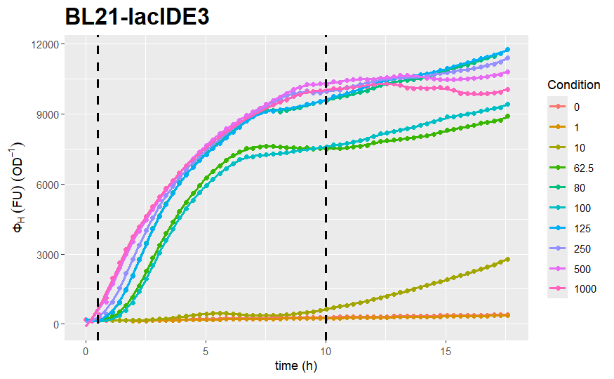

```r
view(BL21_lacI_tidy, 'time', 'phi', 'single', 0.5, 10)
```

This initial visualization is important as a first approximation to the amount of peaks (maximum) or valleys (minimum) present in the time series. For more than one peak, the *maximum method* for dose-response profiling might not be useful, and the *slope-based method* should be applied. For further processing, we select a time interval beginning in $t = 0.5$ h and ending in $t = 10$ h.

```r
time_interval <- list(0.5, 10)
```

### Non-linear regression: Maximum method

Since the non-linear regression method used in this work is the nonlinear least squares (nls), an initial guess is needed. Therefore, it´s useful to first visualize the data in a scatter plot. Each point represents the maximum $\Phi$ value for each concentration of inducer.

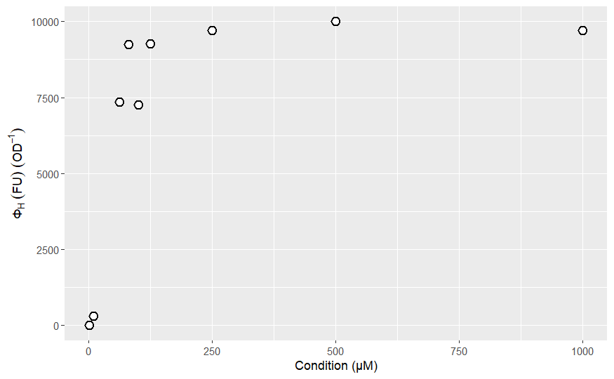

```r
drp <- dose_response_profiling(data = BL21_lacI_tidy,
                               time_interval = time_interval,
                               initial_guess = NaN,
                               flag = FALSE)
print(drp[[1]])
```

Recall the shape of the hill function: $f_H = H \frac{I_i^n}{I_i^n + k_i^n}$. Then, $H$ will be the asymptotic value; $k_i$ controls the concavity of the the curve (i.e the lower the value, the closest the curve is to $y = x$); and $n$ controls the slope of the inflexion point (i.e the higher the value, the steeper the rate of change).

```r
initial_guess <- list(H = 8000, ki = 50, n = 2)
out <- dose_response_profiling(BL21_lacI_tidy, time_interval, initial_guess, TRUE)
```

```
Please use `linewidth` instead.
```

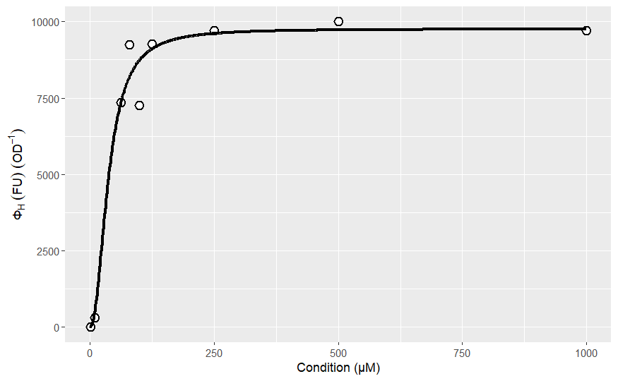

```r
drp <- out[[1]] # dose-response curve
model <- out[[2]] # model
predictions <- out[[3]] # predictions based on hill coefficients
print(drp)
```

A complementary visualization involves comparing the growth rate and heterologous fraction´s time series.

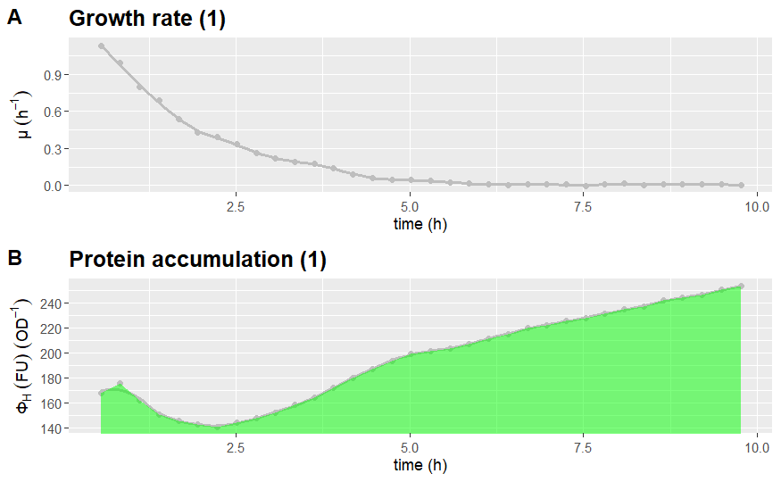

```r
# Selecting a condition
inductor <- unique(BL21_lacI_tidy$Condition)
out <- accumulation(BL21_lacI_tidy, inductor[[2]], time_interval, "bam")

# Plotting
ggpubr::ggarrange(out[[1]],out[[2]],
                  labels = "AUTO",
                  common.legend = T,
                  legend = "bottom",
                  align = "hv",
                  nrow = 2)
```

### Non-linear regression: Slope-based method

Applying the smoothing filter with $n = 5$ windows.

```r
BL21_lacI_tidy <- smooth_filter(BL21_lacI_tidy, 5)
```

We begin by initializing the *linear section* matrix, which contains the time intervals from which the slope between the production and growth rates will be calculated. For this particular case, we notice that the *Condition* column starts at 1 $\mu M$, even though there is an experiment without the addition of inducer. The removal of this data point corresponds to the method used for estimating the hill coefficients in the single-point method, by which the $\Phi_H$ value when there is no inducer (i.e leakiness of the genetic circuit) is subtracted from the other values.

```r
linear_section_matrix <- preliminary_slopes(BL21_lacI_tidy, time_interval)
linear_section_matrix
```

| Condition | Minimum | Maximum | Slope | R2 |
| --- | --- | --- | --- | --- |
| 1.0 | 0.5 | 10 | 116.87596 | 0.609162800 |
| 10.0 | 0.5 | 10 | 31.33022 | 0.001002988 |
| 62.5 | 0.5 | 10 | 6806.33939 | 0.565504538 |
| 80.0 | 0.5 | 10 | 6930.36240 | 0.637545823 |
| 100.0 | 0.5 | 10 | 5882.78730 | 0.507722186 |
| 125.0 | 0.5 | 10 | 6775.34892 | 0.640908393 |
| 250.0 | 0.5 | 10 | 6498.02474 | 0.626795893 |
| 500.0 | 0.5 | 10 | 5863.30887 | 0.599070994 |
| 1000.0 | 0.5 | 10 | 6793.61923 | 0.706492702 |

We begin by generating the hook plot for each experimental condition.

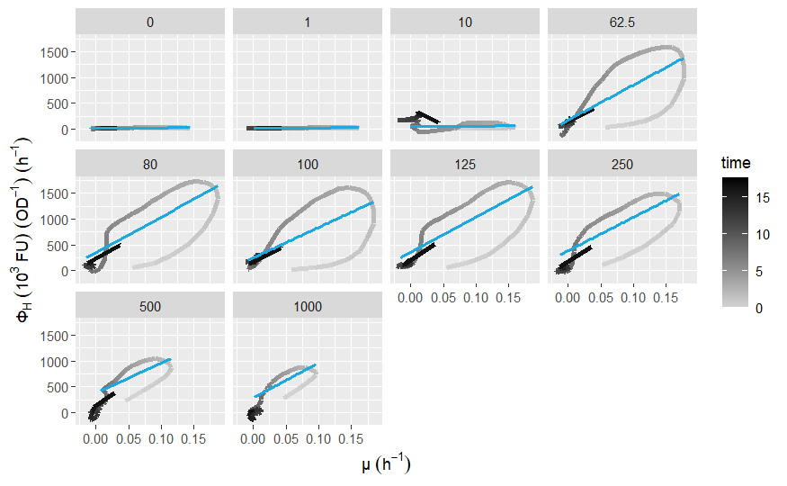

```r
hplot <- rates_plot(BL21_lacI_tidy, linear_section_matrix)
print(hplot)
```

We can manually adjust the *minimum* and *maximum* values as needed. For this step, the $R^2$ value is used as a guiding metric. Recall that inductor[[1]] is not used for the analysis as it´s not part of the previous matrix

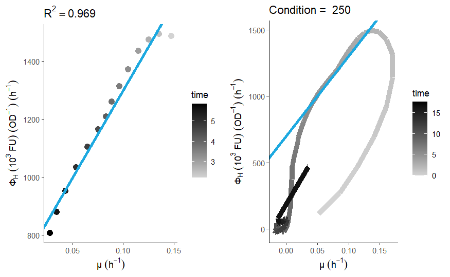

```r
inductor <- unique(BL21_lacI_tidy$Condition)
result_plots <- linear_view(BL21_lacI_tidy, inductor[[8]], time_interval, t1 = 2, t2 = 6)

ggarrange(result_plots[[1]], result_plots[[2]], ncol = 2)
```

In this case, it seems that between the range $t_1 = 2$ h and $t_2 = 6$ h, the $R^2$ value is maximized and considers a great amount of data points. Therefore, we update the *linear_section_matrix*.

```r
time_range <- c(2, 6)
for (condition in linear_section_matrix$Condition) {

  linear_section_matrix <- manual_adjust(BL21_lacI_tidy, linear_section_matrix, condition, t1 = time_range[[1]], t2 = time_range[[2]])
}

linear_section_matrix
```

| Condition | Minimum | Maximum | Slope | R2 |
| --- | --- | --- | --- | --- |
| 1.0 | 2 | 6 | 153.2074 | 0.7942635 |
| 10.0 | 2 | 6 | 981.4001 | 0.5605217 |
| 62.5 | 2 | 6 | 5327.0224 | 0.7560340 |
| 80.0 | 2 | 6 | 6076.0125 | 0.9454543 |
| 100.0 | 2 | 6 | 5511.7950 | 0.7510806 |
| 125.0 | 2 | 6 | 6138.8601 | 0.9460465 |
| 250.0 | 2 | 6 | 6025.3844 | 0.9693804 |
| 500.0 | 2 | 6 | 6020.6166 | 0.8922391 |
| 1000.0 | 2 | 6 | 6198.2699 | 0.9332219 |

We can visually evaluate the results.

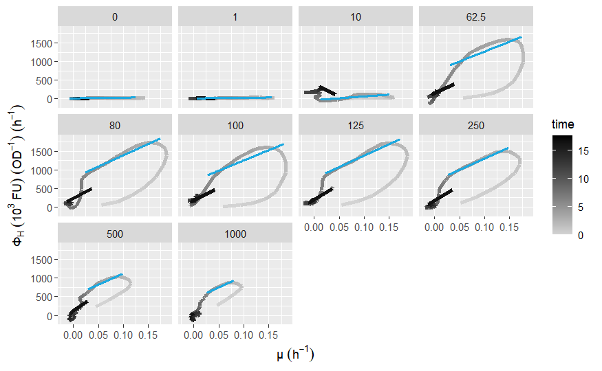

```r
hplot <- rates_plot(BL21_lacI_tidy, linear_section_matrix)
print(hplot)
```

As a complementary plot, we overlap the hook plots with annotations (red circles: maximum growth rate; black squares: maximum heterologous fraction). Two types of visualizations are available: the overlap of all experimental conditions for an overall comparison, or focusing in a single experimental condition. **IMPORTANT**: since there is no sense of “time” in this plot, the visualization needs to be complemented.

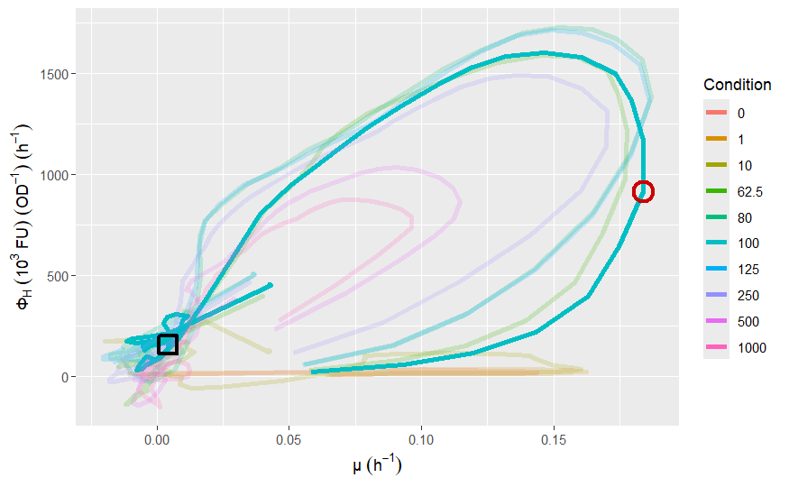

```r
hook_plot(data = BL21_lacI_tidy,
          time_limits = time_interval,
          highlight = TRUE,
          condition = 100)
```

Following the previous method for the hill function using the single-point method, we generate a new hill function based on the slopes.

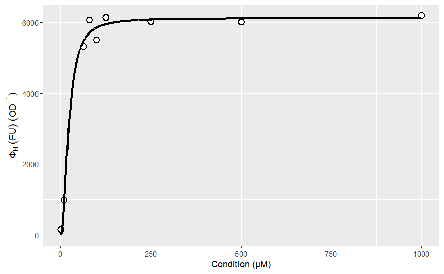

```r
initial_guess <- list(H = 9000, ki = 50, n = 2)
out <- dose_response_profiling(linear_section_matrix, time_interval, initial_guess, TRUE)
drp_slope <- out[[1]]
model_slope <- out[[2]]
predictions_slope <- out[[3]]
print(drp_slope)
```

We will save this coefficients in a dataframe for comparison.

```r
# Hill coefficients
fitting_max <- as.data.frame(summary(model)$parameters)
fitting_slope <- as.data.frame(summary(model_slope)$parameters)

hill_parameters <- data.frame(
  'Strain' = 'BL21 lacI',
  'H_maxima' = sprintf("%.3f ± %.3f", fitting_max$Estimate[[1]], fitting_max$`Std. Error`[[1]]),
  'H_slope' = sprintf("%.3f ± %.3f", fitting_slope$Estimate[[1]], fitting_slope$`Std. Error`[[1]]),
  'ki_maxima' = sprintf("%.3f ± %.3f", fitting_max$Estimate[[2]], fitting_max$`Std. Error`[[2]]),
  'ki_slope' = sprintf("%.3f ± %.3f", fitting_slope$Estimate[[2]], fitting_slope$`Std. Error`[[2]]),
  'n_maxima' = sprintf("%.3f ± %.3f", fitting_max$Estimate[[3]], fitting_max$`Std. Error`[[3]]),
  'n_slope' = sprintf("%.3f ± %.3f", fitting_slope$Estimate[[3]], fitting_slope$`Std. Error`[[3]]),
  'interval' = sprintf("start: %.2f, end: %.2f", time_range[[1]] , time_range[[2]])
)
hill_parameters
```

| Strain | H_maxima | H_slope | ki_maxima | ki_slope | n_maxima | n_slope | interval |
| --- | --- | --- | --- | --- | --- | --- | --- |
| BL21 lacI | 9760.713 ± 454.877 | 6120.867 ± 137.495 | 37.389 ± 8.867 | 22.319 ± 2.788 | 2.187 ± 0.746 | 2.067 ± 0.270 | start: 2.00, end: 6.00 |

```r
# Comparing hill equations
predictions$strain <- rep("BL21 DE3", nrow(predictions))
hill_comparison <- predictions
```

Visual comparison.

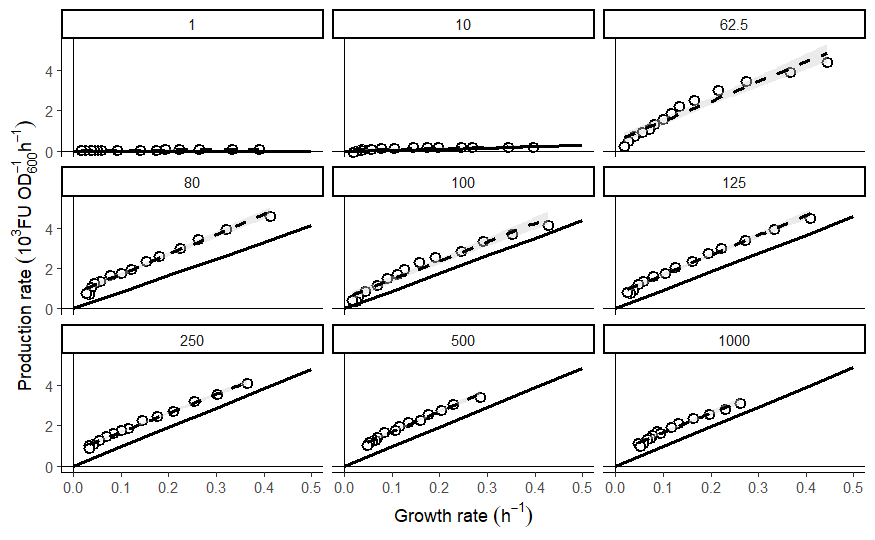

```r
compare_plot <- hill_prediction(data = BL21_lacI_tidy,
                                model_fit = predictions,
                                time_interval = c(2,6),
                                growth_interval = c(0,0.5))
print(compare_plot)
```

This analysis exemplified the data analysis pipeline using the BL21 lacI strain. We will extend this analysis to the rest of IPTG biosensors available.

### BLR and BLR lacI

Uploading the data.

```r
BLR_tidy <- read_csv('./data_raw/ACS/raw_tibble/BLRDE3_Hlim.csv')
head(BLR_tidy)
```

| time | od | flu | phi | growth_rate | production_rate | Condition | strain |
| --- | --- | --- | --- | --- | --- | --- | --- |
| 0.0000000 | 0.084375 | 48.00 | 577.9666 | 0.3014387 | 246.0224 | 1 | BLRDE3 |
| 0.2838889 | 0.086500 | 55.00 | 643.5791 | 0.5554978 | 204.5318 | 1 | BLRDE3 |
| 0.5675000 | 0.090400 | 60.00 | 671.2165 | 0.7756072 | 227.0255 | 1 | BLRDE3 |
| 0.8513889 | 0.100600 | 64.50 | 647.8064 | 0.9580612 | 195.4779 | 1 | BLRDE3 |
| 1.1350000 | 0.116775 | 70.50 | 608.8569 | 1.0579454 | 155.2307 | 1 | BLRDE3 |
| 1.4186111 | 0.142000 | 76.25 | 540.5329 | 1.0858142 | 107.5968 | 1 | BLRDE3 |

Visualizing the data and selecting the time interval.

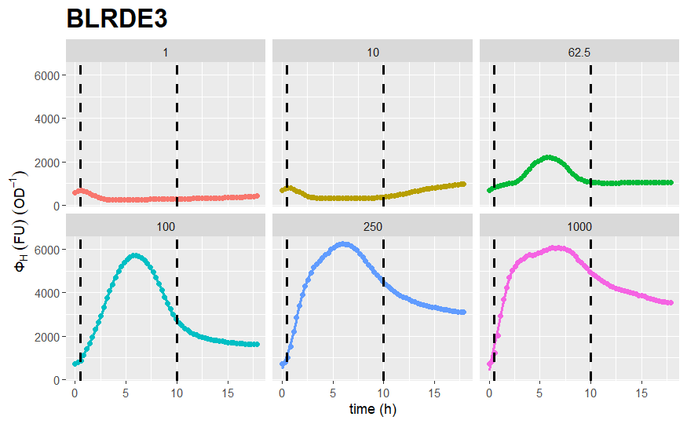

```r
view(BLR_tidy, 'time', 'phi', 'multiple', 0.5, 10)
```

```r
time_interval <- list(0.5, 10)
```

Estimating the hill coefficients using the maximum method.

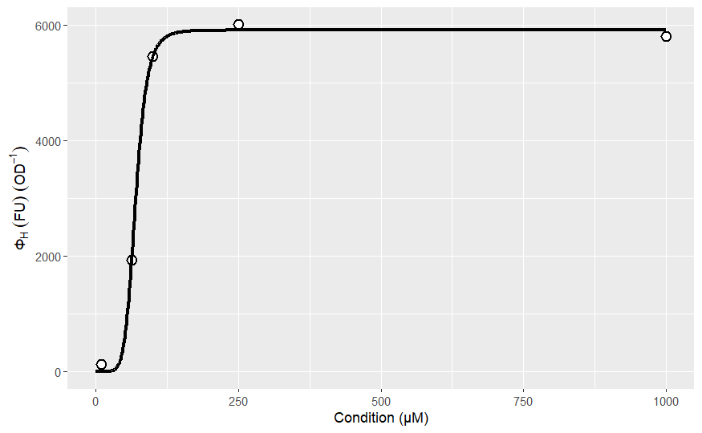

```r
initial_guess <- list(H = 8000, ki = 50, n = 2)
out <- dose_response_profiling(BLR_tidy, time_interval, initial_guess, TRUE)
drp <- out[[1]] # dose-response curve
model <- out[[2]] # model
predictions <- out[[3]] # predictions based on hill coefficients
print(drp)
```

Initializing the *linear section* matrix.

```r
BLR_tidy <- smooth_filter(BLR_tidy, 5)
linear_section_matrix <- preliminary_slopes(BLR_tidy, time_interval)
linear_section_matrix
```

| Condition | Minimum | Maximum | Slope | R2 |
| --- | --- | --- | --- | --- |
| 10.0 | 0.5 | 10 | 16.66098 | 0.009234618 |
| 62.5 | 0.5 | 10 | 3703.51036 | 0.632908101 |
| 100.0 | 0.5 | 10 | 11843.66280 | 0.873010084 |
| 250.0 | 0.5 | 10 | 10195.56443 | 0.913840981 |
| 1000.0 | 0.5 | 10 | 8861.68756 | 0.863362881 |

Generating the hook plot for each experimental condition.

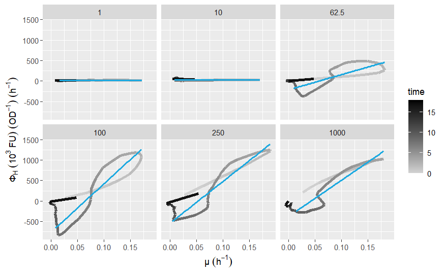

```r
hplot <- rates_plot(BLR_tidy, linear_section_matrix)
print(hplot)
```

Manually adjusting the time interval.

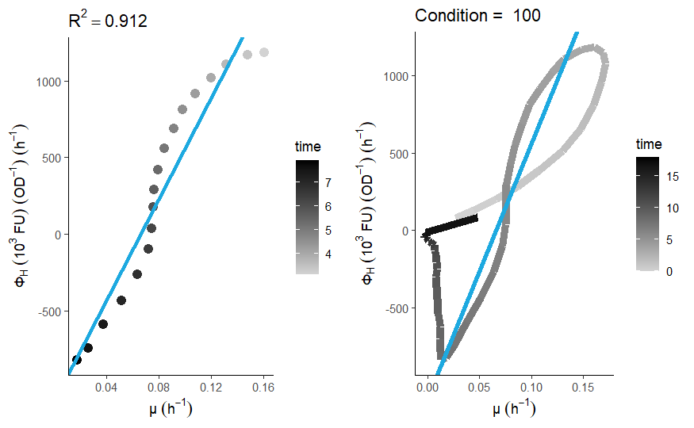

```r
inductor <- unique(BLR_tidy$Condition)
result_plots <- linear_view(BLR_tidy, inductor[[4]], time_interval, t1 = 3, t2 = 8)

ggarrange(result_plots[[1]], result_plots[[2]], ncol = 2)
```

After iterating, it seems difficult to directly set the range of linearity. We will then hard-compute the $t_1$ and $t_2$ combinations.

```r
# Initial parameters
initial_guess <- list(H = 6000, ki = 50, n = 2)

if (exists("drp_slope")) {
      rm(drp_slope)
    }

# Iterate over values of t1 and t2
for (t1 in seq(0.5, 4, by = 0.1)) {
  for (t2 in seq(10, 5, by = -0.5)) {
    # Apply manual_adjust function
    for (condition in linear_section_matrix$Condition) {
      linear_section_matrix <- manual_adjust(BLR_tidy, linear_section_matrix, condition, t1 = t1, t2 = t2)
    }
    # Apply dose_response_profiling function with try-catch
    tryCatch({
      drp_slope <- dose_response_profiling(linear_section_matrix, time_interval, initial_guess, TRUE)
      # Check if nls algorithm converged
      if (!is.null(drp_slope[[1]])) {
        # Print the combination of t1 and t2
        cat("Converged: t1 =", t1, ", t2 =", t2, "\n")
      }
    }, error = function(e) {
      # If an error occurs, print a message indicating that the combination failed to converge
      #cat("Failed to converge: t1 =", t1, ", t2 =", t2, "\n")
    })

    # Remove drp_slope if it exists
    if (exists("drp_slope")) {
      rm(drp_slope)
    }
  }
}
```

```
Converged: t1 = 1.8 , t2 = 5
Converged: t1 = 1.9 , t2 = 5
```

Adjusting the *linear section* matrix accordingly.

```r
time_range <- c(1.9, 5)
for (condition in linear_section_matrix$Condition) {

  linear_section_matrix <- manual_adjust(BLR_tidy, linear_section_matrix, condition,
                                         t1 = time_range[[1]], t2 = time_range[[2]])
}

linear_section_matrix
```

| Condition | Minimum | Maximum | Slope | R2 |
| --- | --- | --- | --- | --- |
| 10.0 | 1.9 | 5 | 9.244584 | 0.01817484 |
| 62.5 | 1.9 | 5 | 237.598189 | 0.01220332 |
| 100.0 | 1.9 | 5 | 3471.089265 | 0.39323841 |
| 250.0 | 1.9 | 5 | 4236.773541 | 0.86548085 |
| 1000.0 | 1.9 | 5 | 3396.874268 | 0.91223471 |

Visualizing,

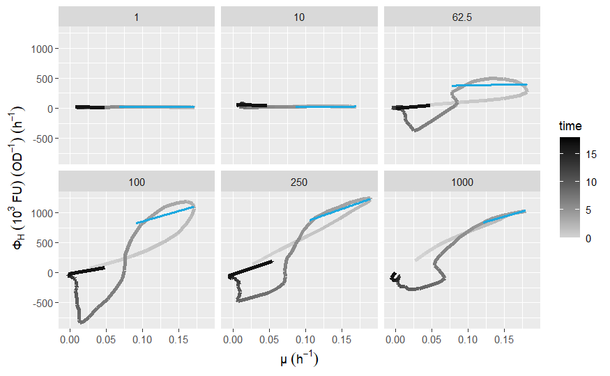

```r
hplot <- rates_plot(BLR_tidy, linear_section_matrix)
print(hplot)
```

Complementary hook plot.

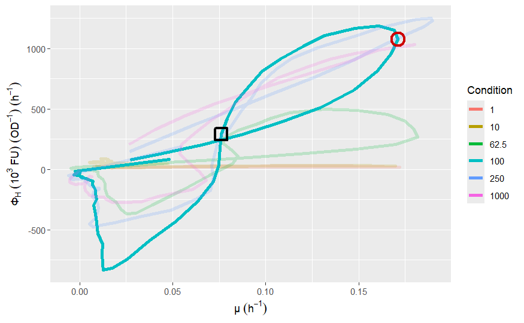

```r
hook_plot(data = BLR_tidy,
          time_limits = time_interval,
          highlight = TRUE,
          condition = 100)
```

Generating the slope-based dose-response profile.

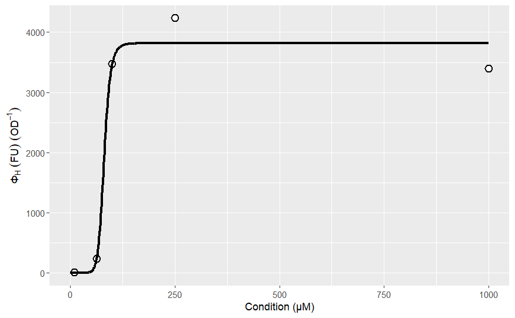

```r
initial_guess <- list(H = 6000, ki = 50, n = 2)
out <- dose_response_profiling(linear_section_matrix, time_interval, initial_guess, TRUE)
drp_slope <- out[[1]]
model_slope <- out[[2]]
predictions_slope <- out[[3]]
print(drp_slope)
```

We will save this coefficients in a dataframe for comparison.

```r
# Hill coefficients
fitting_max <- as.data.frame(summary(model)$parameters)
fitting_slope <- as.data.frame(summary(model_slope)$parameters)

anex <- data.frame(
  'Strain' = 'BLR',
  'H_maxima' = sprintf("%.3f ± %.3f", fitting_max$Estimate[[1]], fitting_max$`Std. Error`[[1]]),
  'H_slope' = sprintf("%.3f ± %.3f", fitting_slope$Estimate[[1]], fitting_slope$`Std. Error`[[1]]),
  'ki_maxima' = sprintf("%.3f ± %.3f", fitting_max$Estimate[[2]], fitting_max$`Std. Error`[[2]]),
  'ki_slope' = sprintf("%.3f ± %.3f", fitting_slope$Estimate[[2]], fitting_slope$`Std. Error`[[2]]),
  'n_maxima' = sprintf("%.3f ± %.3f", fitting_max$Estimate[[3]], fitting_max$`Std. Error`[[3]]),
  'n_slope' = sprintf("%.3f ± %.3f", fitting_slope$Estimate[[3]], fitting_slope$`Std. Error`[[3]]),
  'interval' = sprintf("start: %.2f, end: %.2f", time_range[[1]] , time_range[[2]])
)

hill_parameters <- rbind(hill_parameters, anex)
hill_parameters
```

| Strain | H_maxima | H_slope | ki_maxima | ki_slope | n_maxima | n_slope | interval |
| --- | --- | --- | --- | --- | --- | --- | --- |
| BL21 lacI | 9760.713 ± 454.877 | 6120.867 ± 137.495 | 37.389 ± 8.867 | 22.319 ± 2.788 | 2.187 ± 0.746 | 2.067 ± 0.270 | start: 2.00, end: 6.00 |
| BLR | 5915.041 ± 95.414 | 3816.798 ± 297.019 | 69.425 ± 1.287 | 80.573 ± 9.317 | 6.865 ± 0.834 | 10.680 ± 5.188 | start: 1.90, end: 5.00 |

```r
# Comparing hill equations
predictions$strain <- rep("BLR", nrow(predictions))
hill_comparison <- rbind(hill_comparison, predictions)
```

Visual comparison,

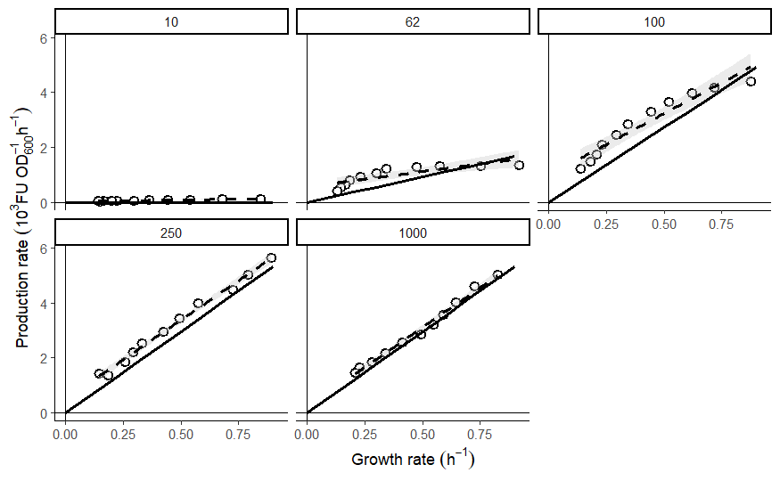

```r
compare_plot <- hill_prediction(data = BLR_tidy,
                                model_fit = predictions,
                                time_interval = time_range,
                                growth_interval = c(0,0.9))
print(compare_plot)
```

Repeating the analysis for the lacI strain.

```r
BLR_lacI_tidy <- read_csv('./data_raw/ACS/raw_tibble/BLR-lacIDE3_Hlim.csv')
head(BLR_lacI_tidy)
```

| time | od | flu | phi | growth_rate | production_rate | Condition | strain |
| --- | --- | --- | --- | --- | --- | --- | --- |
| 0.0000000 | 0.10990 | 8.75 | 81.00689 | 0.2782166 | 89.82284 | 1 | BLR-lacIDE3 |
| 0.2838889 | 0.09290 | 15.00 | 161.53066 | 0.8093350 | 66.72010 | 1 | BLR-lacIDE3 |
| 0.5675000 | 0.10245 | 17.50 | 170.80211 | 1.0594298 | 68.43679 | 1 | BLR-lacIDE3 |
| 0.8513889 | 0.11950 | 19.00 | 159.09172 | 1.0382907 | 51.89126 | 1 | BLR-lacIDE3 |
| 1.1350000 | 0.14420 | 20.50 | 142.23346 | 1.0626196 | 54.62836 | 1 | BLR-lacIDE3 |
| 1.4186111 | 0.17920 | 22.50 | 125.55444 | 0.8169752 | 53.89541 | 1 | BLR-lacIDE3 |

Visualizing the data and selecting the time interval.

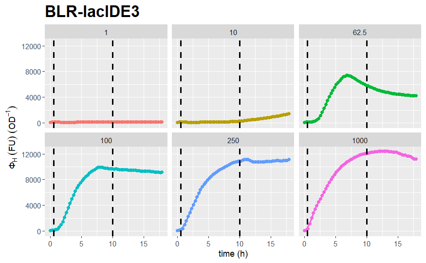

```r
view(BLR_lacI_tidy, 'time', 'phi', 'multiple', 0.5, 10)
```

```r
time_interval <- list(0.5, 10)
```

Estimating the hill coefficients using the maximum method.

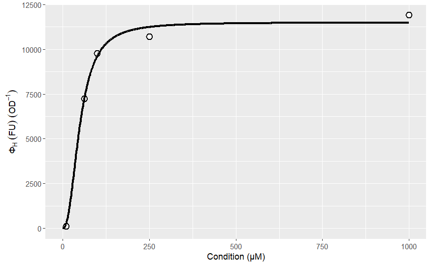

```r
initial_guess <- list(H = 8000, ki = 50, n = 2)
out <- dose_response_profiling(BLR_lacI_tidy, time_interval, initial_guess, TRUE)
drp <- out[[1]] # dose-response curve
model <- out[[2]] # model
predictions <- out[[3]] # predictions based on hill coefficients
print(drp)
```

Initializing the *linear section* matrix.

```r
BLR_lacI_tidy <- smooth_filter(BLR_lacI_tidy, 5)
linear_section_matrix <- preliminary_slopes(BLR_lacI_tidy, time_interval)
linear_section_matrix
```

| Condition | Minimum | Maximum | Slope | R2 |
| --- | --- | --- | --- | --- |
| 10.0 | 0.5 | 10 | -135.0071 | 0.09910582 |
| 62.5 | 0.5 | 10 | 9512.7971 | 0.58727727 |
| 100.0 | 0.5 | 10 | 9151.9846 | 0.58844792 |
| 250.0 | 0.5 | 10 | 6430.4766 | 0.53203585 |
| 1000.0 | 0.5 | 10 | 6982.6871 | 0.50636418 |

Generating the hook plot for each experimental condition.

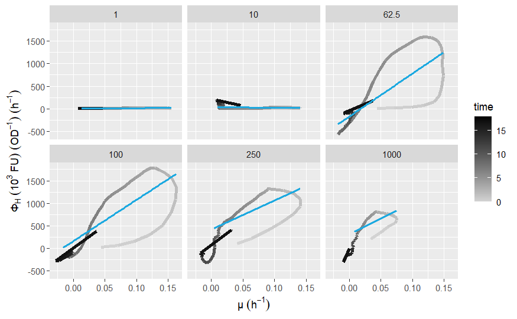

```r
hplot <- rates_plot(BLR_lacI_tidy, linear_section_matrix)
print(hplot)
```

Manually adjusting the time interval.

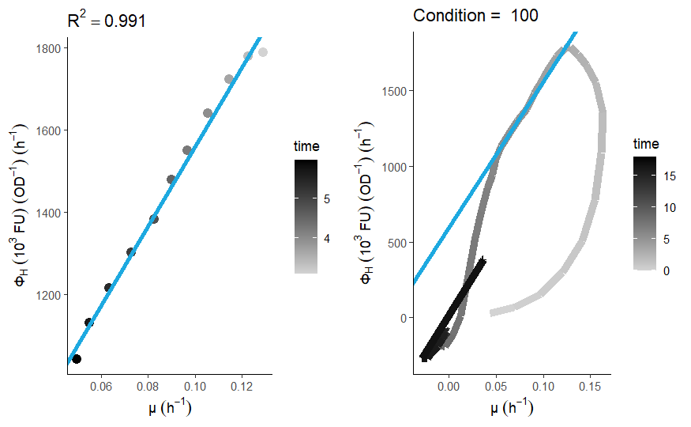

```r
inductor <- unique(BLR_lacI_tidy$Condition)
result_plots <- linear_view(BLR_lacI_tidy, inductor[[4]], time_interval, t1 = 3, t2 = 6)

ggarrange(result_plots[[1]], result_plots[[2]], ncol = 2)
```

Adjusting the *linear section* matrix accordingly.

```r
time_range <- c(3, 6)
for (condition in linear_section_matrix$Condition) {

  linear_section_matrix <- manual_adjust(BLR_lacI_tidy, linear_section_matrix, condition,
                                         t1 = time_range[[1]], t2 = time_range[[2]])
}

linear_section_matrix
```

| Condition | Minimum | Maximum | Slope | R2 |
| --- | --- | --- | --- | --- |
| 10.0 | 3 | 6 | 373.1759 | 0.8338763 |
| 62.5 | 3 | 6 | 8835.0547 | 0.8325445 |
| 100.0 | 3 | 6 | 9669.8364 | 0.9912563 |
| 250.0 | 3 | 6 | 10457.5417 | 0.9965675 |
| 1000.0 | 3 | 6 | 12225.9116 | 0.9768879 |

Visualizing,

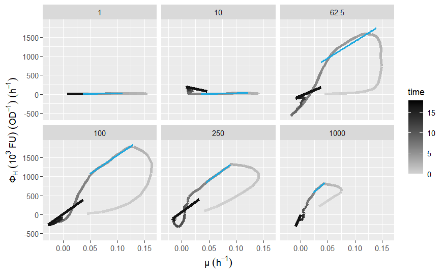

```r
hplot <- rates_plot(BLR_lacI_tidy, linear_section_matrix)
print(hplot)
```

Complementary hook plot.

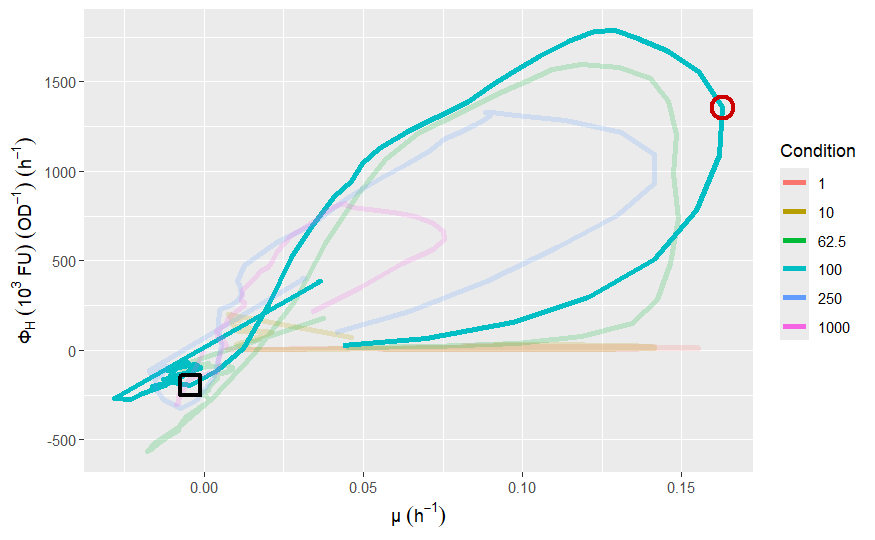

```r
hook_plot(data = BLR_lacI_tidy,
          time_limits = time_interval,
          highlight = TRUE,
          condition = 100)
```

Generating the slope-based dose-response profile.

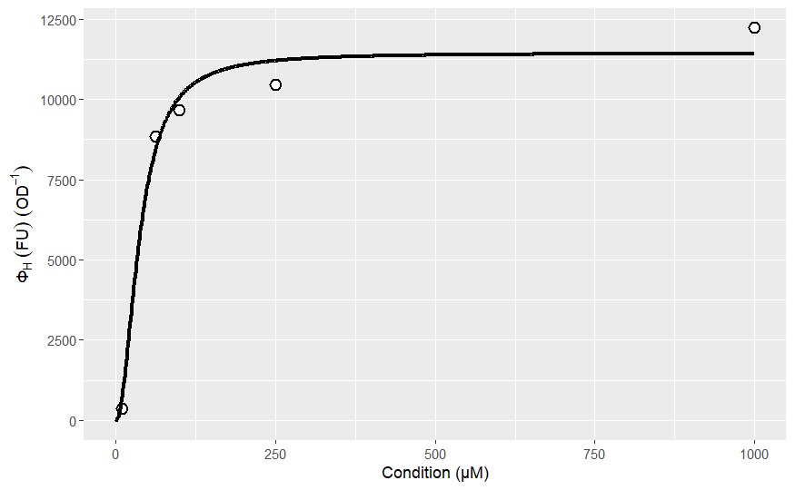

```r
initial_guess <- list(H = 6000, ki = 50, n = 2)
out <- dose_response_profiling(linear_section_matrix, time_interval, initial_guess, TRUE)
drp_slope <- out[[1]]
model_slope <- out[[2]]
predictions_slope <- out[[3]]
print(drp_slope)
```

We will save this coefficients in a dataframe for comparison.

```r
# Hill coefficients
fitting_max <- as.data.frame(summary(model)$parameters)
fitting_slope <- as.data.frame(summary(model_slope)$parameters)

anex <- data.frame(
  'Strain' = 'BLR lacI',
  'H_maxima' = sprintf("%.3f ± %.3f", fitting_max$Estimate[[1]], fitting_max$`Std. Error`[[1]]),
  'H_slope' = sprintf("%.3f ± %.3f", fitting_slope$Estimate[[1]], fitting_slope$`Std. Error`[[1]]),
  'ki_maxima' = sprintf("%.3f ± %.3f", fitting_max$Estimate[[2]], fitting_max$`Std. Error`[[2]]),
  'ki_slope' = sprintf("%.3f ± %.3f", fitting_slope$Estimate[[2]], fitting_slope$`Std. Error`[[2]]),
  'n_maxima' = sprintf("%.3f ± %.3f", fitting_max$Estimate[[3]], fitting_max$`Std. Error`[[3]]),
  'n_slope' = sprintf("%.3f ± %.3f", fitting_slope$Estimate[[3]], fitting_slope$`Std. Error`[[3]]),
  'interval' = sprintf("start: %.2f, end: %.2f", time_range[[1]] , time_range[[2]])
)

hill_parameters <- rbind(hill_parameters, anex)
hill_parameters
```

| Strain | H_maxima | H_slope | ki_maxima | ki_slope | n_maxima | n_slope | interval |
| --- | --- | --- | --- | --- | --- | --- | --- |
| BL21 lacI | 9760.713 ± 454.877 | 6120.867 ± 137.495 | 37.389 ± 8.867 | 22.319 ± 2.788 | 2.187 ± 0.746 | 2.067 ± 0.270 | start: 2.00, end: 6.00 |
| BLR | 5915.041 ± 95.414 | 3816.798 ± 297.019 | 69.425 ± 1.287 | 80.573 ± 9.317 | 6.865 ± 0.834 | 10.680 ± 5.188 | start: 1.90, end: 5.00 |
| BLR lacI | 11499.996 ± 413.017 | 11433.653 ± 702.010 | 49.589 ± 5.481 | 37.585 ± 9.187 | 2.338 ± 0.663 | 2.039 ± 0.709 | start: 3.00, end: 6.00 |

```r
# Comparing hill equations
predictions$strain <- rep("BLR lacI", nrow(predictions))
hill_comparison <- rbind(hill_comparison, predictions)
```

Visual comparison,

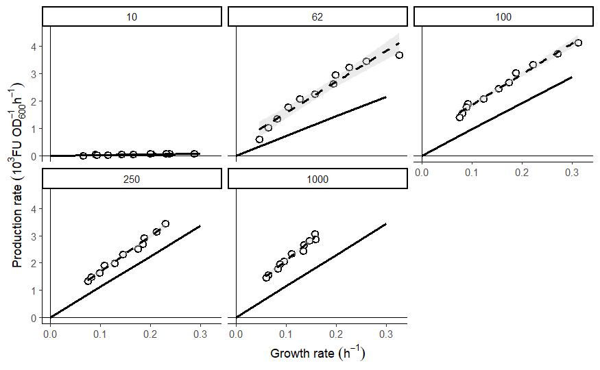

```r
compare_plot <- hill_prediction(data = BLR_lacI_tidy,
                                model_fit = predictions,
                                time_interval = time_range,
                                growth_interval = c(0,0.3))
print(compare_plot)
```

### MG1655 and MG1655 lacI

Uploading the data.

```r
MG1655_tidy <- read_csv('./data_raw/ACS/raw_tibble/MG1655DE3_Hlim.csv')
head(MG1655_tidy)
```

| time | od | flu | phi | growth_rate | production_rate | Condition | strain |
| --- | --- | --- | --- | --- | --- | --- | --- |
| 0.0000000 | 0.10130 | 7.25 | 71.73727 | 0.3533920 | 85.23599 | 1 | MG1655DE3 |
| 0.2838889 | 0.10860 | 13.50 | 124.46176 | 0.4971375 | 80.91210 | 1 | MG1655DE3 |
| 0.5675000 | 0.11665 | 16.25 | 139.45664 | 0.5899445 | 45.12457 | 1 | MG1655DE3 |
| 0.8513889 | 0.12855 | 18.00 | 140.10597 | 0.7893202 | 68.81422 | 1 | MG1655DE3 |
| 1.1350000 | 0.14355 | 19.75 | 137.67333 | 0.9438697 | 43.05966 | 1 | MG1655DE3 |
| 1.4186111 | 0.16770 | 21.75 | 129.70509 | 0.9971611 | 52.39965 | 1 | MG1655DE3 |

Visualizing the data and selecting the time interval.

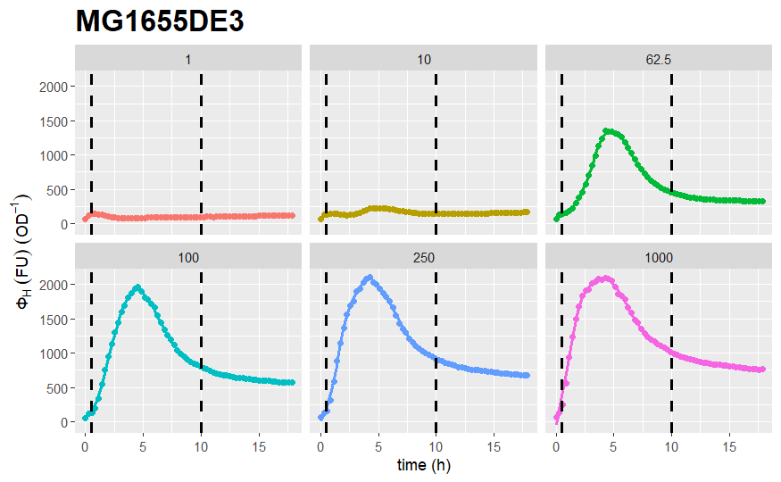

```r
view(MG1655_tidy, 'time', 'phi', 'multiple', 0.5, 10)
```

```r
time_interval <- list(0.5, 10)
```

Estimating the hill coefficients using the maximum method.

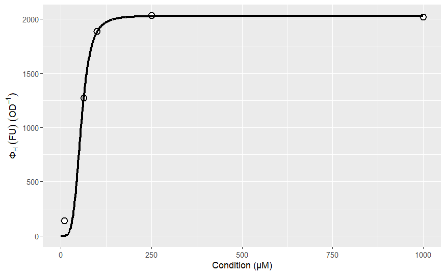

```r
initial_guess <- list(H = 8000, ki = 50, n = 2)
out <- dose_response_profiling(MG1655_tidy, time_interval, initial_guess, TRUE)
drp <- out[[1]] # dose-response curve
model <- out[[2]] # model
predictions <- out[[3]] # predictions based on hill coefficients
print(drp)
```

Initializing the *linear section* matrix.

```r
MG1655_tidy <- smooth_filter(MG1655_tidy, 5)
linear_section_matrix <- preliminary_slopes(MG1655_tidy, time_interval)
linear_section_matrix
```

| Condition | Minimum | Maximum | Slope | R2 |
| --- | --- | --- | --- | --- |
| 10.0 | 0.5 | 10 | 320.575 | 0.7325130 |
| 62.5 | 0.5 | 10 | 2535.962 | 0.8180782 |
| 100.0 | 0.5 | 10 | 3416.942 | 0.9121099 |
| 250.0 | 0.5 | 10 | 3397.200 | 0.9004560 |
| 1000.0 | 0.5 | 10 | 3192.163 | 0.8967942 |

Generating the hook plot for each experimental condition.

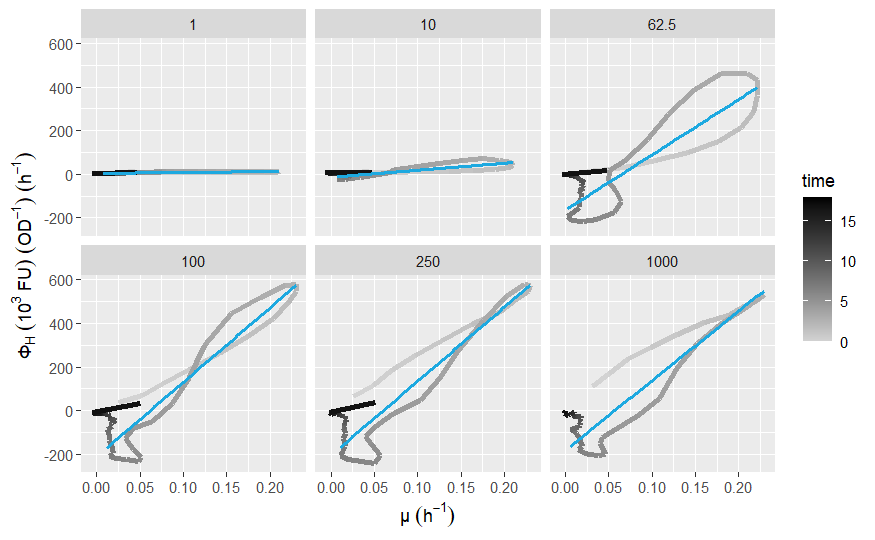

```r
hplot <- rates_plot(MG1655_tidy, linear_section_matrix)
print(hplot)
```

Manually adjusting the time interval.

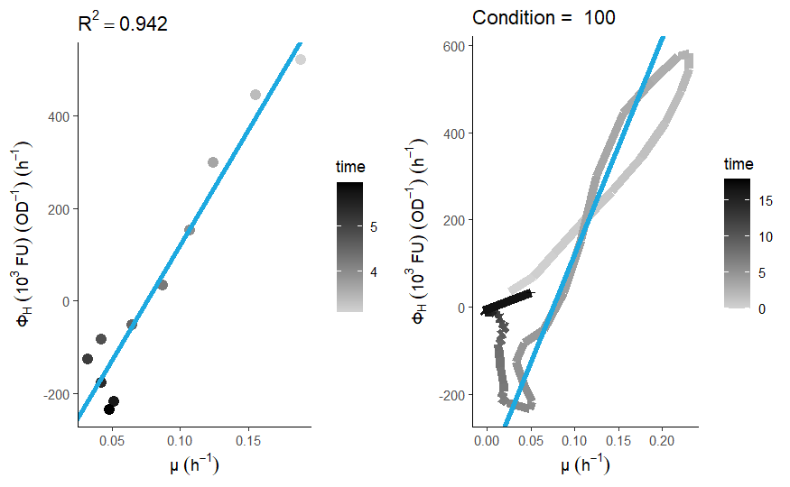

```r
inductor <- unique(MG1655_tidy$Condition)
result_plots <- linear_view(MG1655_tidy, inductor[[4]], time_interval, t1 = 3, t2 = 6)

ggarrange(result_plots[[1]], result_plots[[2]], ncol = 2)
```

Adjusting the *linear section* matrix accordingly.

```r
time_range <- c(2, 8)
for (condition in linear_section_matrix$Condition) {

  linear_section_matrix <- manual_adjust(MG1655_tidy, linear_section_matrix, condition,
                                         t1 = time_range[[1]], t2 = time_range[[2]])
}

linear_section_matrix
```

| Condition | Minimum | Maximum | Slope | R2 |
| --- | --- | --- | --- | --- |
| 10.0 | 2 | 8 | 437.8856 | 0.8841124 |
| 62.5 | 2 | 8 | 3218.6873 | 0.8975844 |
| 100.0 | 2 | 8 | 3921.7595 | 0.9443993 |
| 250.0 | 2 | 8 | 3716.8671 | 0.9507852 |
| 1000.0 | 2 | 8 | 3393.1342 | 0.9582533 |

Visualizing,

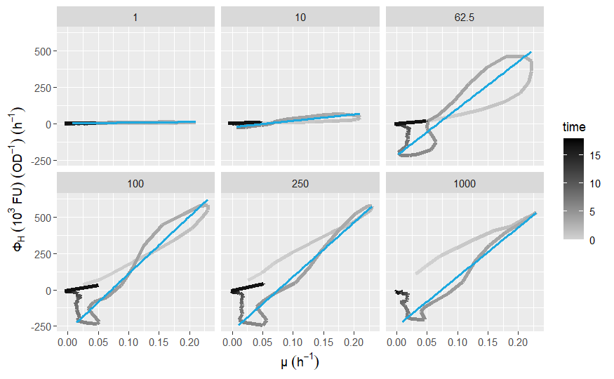

```r
hplot <- rates_plot(MG1655_tidy, linear_section_matrix)
print(hplot)
```

Complementary hook plot.

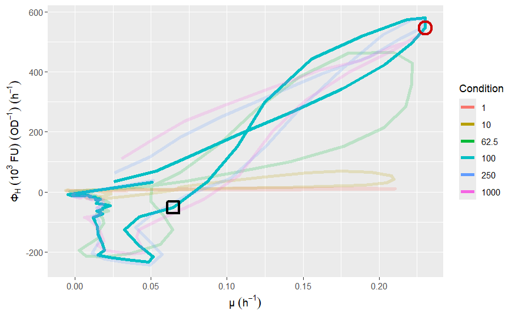

```r
hook_plot(data = MG1655_tidy,
          time_limits = time_interval,
          highlight = TRUE,
          condition = 100)
```

Generating the slope-based dose-response profile.

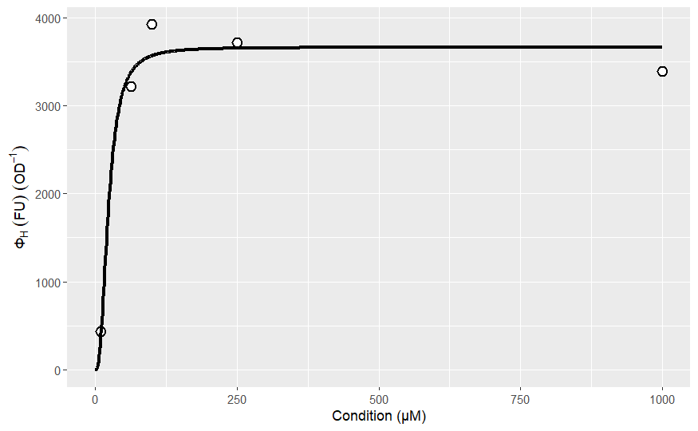

```r
initial_guess <- list(H = 4000, ki = 50, n = 2)
out <- dose_response_profiling(linear_section_matrix, time_interval, initial_guess, TRUE)
drp_slope <- out[[1]]
model_slope <- out[[2]]
predictions_slope <- out[[3]]
print(drp_slope)
```

We will save this coefficients in a dataframe for comparison.

```r
# Hill coefficients
fitting_max <- as.data.frame(summary(model)$parameters)
fitting_slope <- as.data.frame(summary(model_slope)$parameters)

anex <- data.frame(
  'Strain' = 'MG1655',
  'H_maxima' = sprintf("%.3f ± %.3f", fitting_max$Estimate[[1]], fitting_max$`Std. Error`[[1]]),
  'H_slope' = sprintf("%.3f ± %.3f", fitting_slope$Estimate[[1]], fitting_slope$`Std. Error`[[1]]),
  'ki_maxima' = sprintf("%.3f ± %.3f", fitting_max$Estimate[[2]], fitting_max$`Std. Error`[[2]]),
  'ki_slope' = sprintf("%.3f ± %.3f", fitting_slope$Estimate[[2]], fitting_slope$`Std. Error`[[2]]),
  'n_maxima' = sprintf("%.3f ± %.3f", fitting_max$Estimate[[3]], fitting_max$`Std. Error`[[3]]),
  'n_slope' = sprintf("%.3f ± %.3f", fitting_slope$Estimate[[3]], fitting_slope$`Std. Error`[[3]]),
  'interval' = sprintf("start: %.2f, end: %.2f", time_range[[1]] , time_range[[2]])
)

hill_parameters <- rbind(hill_parameters, anex)
hill_parameters
```

| Strain | H_maxima | H_slope | ki_maxima | ki_slope | n_maxima | n_slope | interval |
| --- | --- | --- | --- | --- | --- | --- | --- |
| BL21 lacI | 9760.713 ± 454.877 | 6120.867 ± 137.495 | 37.389 ± 8.867 | 22.319 ± 2.788 | 2.187 ± 0.746 | 2.067 ± 0.270 | start: 2.00, end: 6.00 |
| BLR | 5915.041 ± 95.414 | 3816.798 ± 297.019 | 69.425 ± 1.287 | 80.573 ± 9.317 | 6.865 ± 0.834 | 10.680 ± 5.188 | start: 1.90, end: 5.00 |
| BLR lacI | 11499.996 ± 413.017 | 11433.653 ± 702.010 | 49.589 ± 5.481 | 37.585 ± 9.187 | 2.338 ± 0.663 | 2.039 ± 0.709 | start: 3.00, end: 6.00 |
| MG1655 | 2028.740 ± 72.050 | 3660.828 ± 231.406 | 55.495 ± 4.093 | 22.969 ± 8.297 | 4.368 ± 1.883 | 2.476 ± 0.975 | start: 2.00, end: 8.00 |

```r
# Comparing hill equations
predictions$strain <- rep("MG1655", nrow(predictions))
hill_comparison <- rbind(hill_comparison, predictions)
```

Visual comparison,

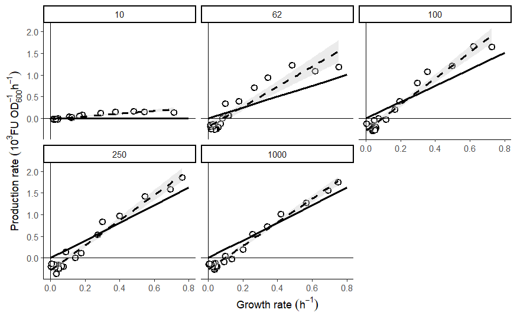

```r
compare_plot <- hill_prediction(data = MG1655_tidy,
                                model_fit = predictions,
                                time_interval = time_range,
                                growth_interval = c(0,0.8))
print(compare_plot)
```

Repeating for the lacI strain.

```r
MG1655_lacI_tidy <- read_csv('./data_raw/ACS/raw_tibble/MG1655-lacIDE3_Hlim.csv')
head(MG1655_lacI_tidy)
```

| time | od | flu | phi | growth_rate | production_rate | Condition | strain |
| --- | --- | --- | --- | --- | --- | --- | --- |
| 0.0000000 | 0.100350 | 5.75 | 57.26277 | 0.3827009 | 98.06889 | 1 | MG1655-lacIDE3 |
| 0.2838889 | 0.106500 | 12.50 | 117.53046 | 0.5494250 | 41.66446 | 1 | MG1655-lacIDE3 |
| 0.5675000 | 0.115750 | 14.75 | 127.49050 | 0.7202069 | 45.54431 | 1 | MG1655-lacIDE3 |
| 0.8513889 | 0.129200 | 16.00 | 124.00132 | 0.8670782 | 20.87117 | 1 | MG1655-lacIDE3 |
| 1.1350000 | 0.146925 | 17.00 | 115.81752 | 0.9690526 | 36.00941 | 1 | MG1655-lacIDE3 |
| 1.4186111 | 0.174075 | 18.00 | 103.49399 | 0.9687840 | 30.13125 | 1 | MG1655-lacIDE3 |

Visualizing the data and selecting the time interval.

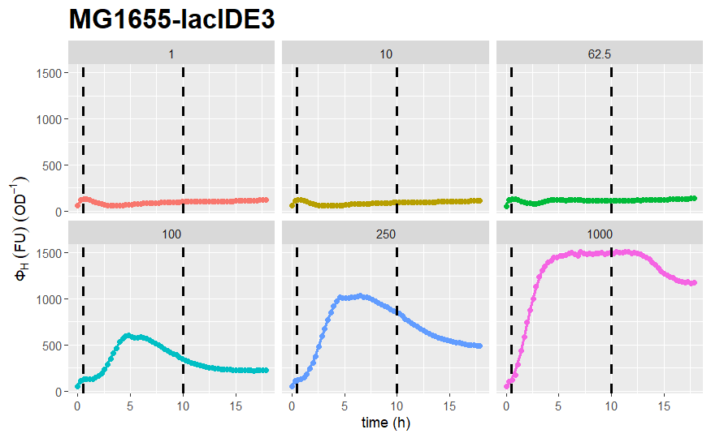

```r
view(MG1655_lacI_tidy, 'time', 'phi', 'multiple', 0.5, 10)
```

```r
time_interval <- list(0.5, 10)
```

Estimating the hill coefficients using the maximum method.

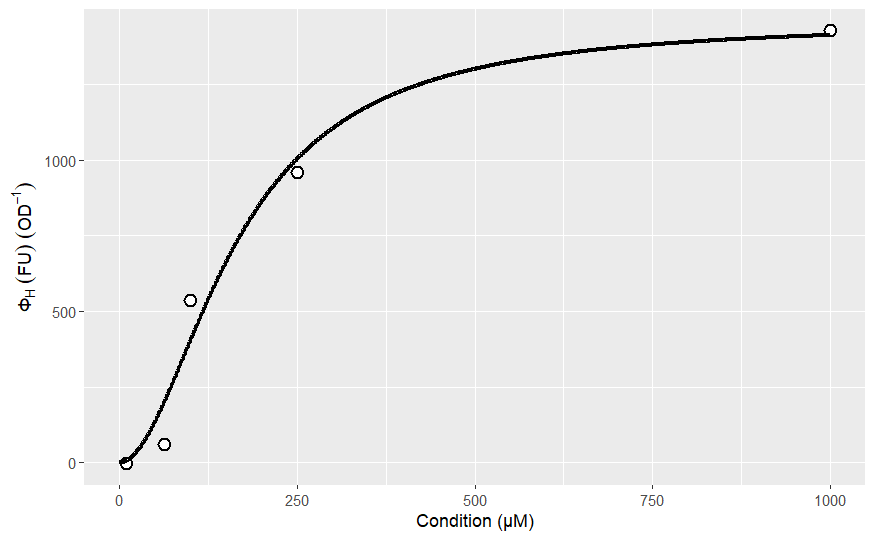

```r
initial_guess <- list(H = 8000, ki = 50, n = 2)
out <- dose_response_profiling(MG1655_lacI_tidy, time_interval, initial_guess, TRUE)
drp <- out[[1]] # dose-response curve
model <- out[[2]] # model
predictions <- out[[3]] # predictions based on hill coefficients
print(drp)
```

Initializing the *linear section* matrix.

```r
MG1655_lacI_tidy <- smooth_filter(MG1655_lacI_tidy, 5)
linear_section_matrix <- preliminary_slopes(MG1655_lacI_tidy, time_interval)
linear_section_matrix
```

| Condition | Minimum | Maximum | Slope | R2 |
| --- | --- | --- | --- | --- |
| 10.0 | 0.5 | 10 | 21.26183 | 0.2338352 |
| 62.5 | 0.5 | 10 | 118.07029 | 0.5976264 |
| 100.0 | 0.5 | 10 | 1122.80134 | 0.6450020 |
| 250.0 | 0.5 | 10 | 1522.13074 | 0.5757079 |
| 1000.0 | 0.5 | 10 | 2260.72674 | 0.9249548 |

Generating the hook plot for each experimental condition.

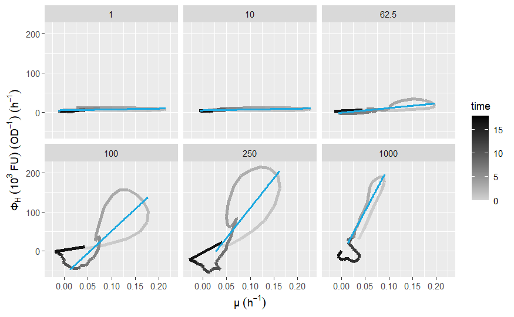

```r
hplot <- rates_plot(MG1655_lacI_tidy, linear_section_matrix)
print(hplot)
```

Manually adjusting the time interval.

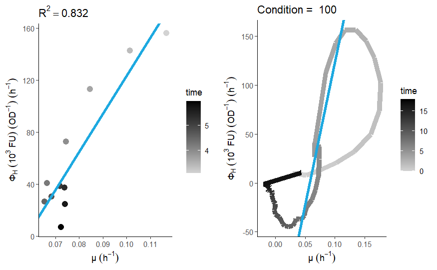

```r
inductor <- unique(MG1655_lacI_tidy$Condition)
result_plots <- linear_view(MG1655_lacI_tidy, inductor[[4]], time_interval, t1 = 3, t2 = 6)

ggarrange(result_plots[[1]], result_plots[[2]], ncol = 2)
```

Adjusting the *linear section* matrix accordingly.

```r
time_range <- c(0.5, 10)
for (condition in linear_section_matrix$Condition) {

  linear_section_matrix <- manual_adjust(MG1655_lacI_tidy, linear_section_matrix, condition,
                                         t1 = time_range[[1]], t2 = time_range[[2]])
}

linear_section_matrix
```

| Condition | Minimum | Maximum | Slope | R2 |
| --- | --- | --- | --- | --- |
| 10.0 | 0.5 | 10 | 21.26183 | 0.2338352 |
| 62.5 | 0.5 | 10 | 118.07029 | 0.5976264 |
| 100.0 | 0.5 | 10 | 1122.80134 | 0.6450020 |
| 250.0 | 0.5 | 10 | 1522.13074 | 0.5757079 |
| 1000.0 | 0.5 | 10 | 2260.72674 | 0.9249548 |

Visualizing,

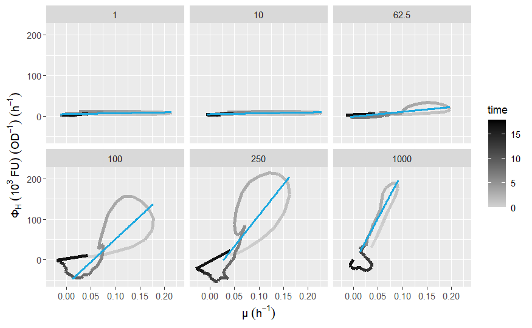

```r
hplot <- rates_plot(MG1655_lacI_tidy, linear_section_matrix)
print(hplot)
```

Complementary hook plot.

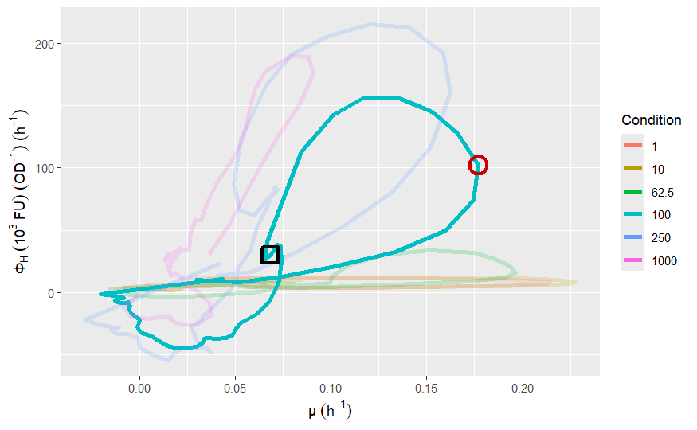

```r
hook_plot(data = MG1655_lacI_tidy,
          time_limits = time_interval,
          highlight = TRUE,
          condition = 100)
```

Generating the slope-based dose-response profile.

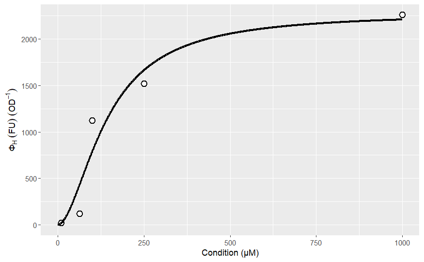

```r
initial_guess <- list(H = 4000, ki = 50, n = 2)
out <- dose_response_profiling(linear_section_matrix, time_interval, initial_guess, TRUE)
drp_slope <- out[[1]]
model_slope <- out[[2]]
predictions_slope <- out[[3]]
print(drp_slope)
```

We will save this coefficients in a dataframe for comparison.

```r
# Hill coefficients
fitting_max <- as.data.frame(summary(model)$parameters)
fitting_slope <- as.data.frame(summary(model_slope)$parameters)

anex <- data.frame(
  'Strain' = 'MG1655 lacI',
  'H_maxima' = sprintf("%.3f ± %.3f", fitting_max$Estimate[[1]], fitting_max$`Std. Error`[[1]]),
  'H_slope' = sprintf("%.3f ± %.3f", fitting_slope$Estimate[[1]], fitting_slope$`Std. Error`[[1]]),
  'ki_maxima' = sprintf("%.3f ± %.3f", fitting_max$Estimate[[2]], fitting_max$`Std. Error`[[2]]),
  'ki_slope' = sprintf("%.3f ± %.3f", fitting_slope$Estimate[[2]], fitting_slope$`Std. Error`[[2]]),
  'n_maxima' = sprintf("%.3f ± %.3f", fitting_max$Estimate[[3]], fitting_max$`Std. Error`[[3]]),
  'n_slope' = sprintf("%.3f ± %.3f", fitting_slope$Estimate[[3]], fitting_slope$`Std. Error`[[3]]),
  'interval' = sprintf("start: %.2f, end: %.2f", time_range[[1]] , time_range[[2]])
)

hill_parameters <- rbind(hill_parameters, anex)
hill_parameters
```

| Strain | H_maxima | H_slope | ki_maxima | ki_slope | n_maxima | n_slope | interval |
| --- | --- | --- | --- | --- | --- | --- | --- |
| BL21 lacI | 9760.713 ± 454.877 | 6120.867 ± 137.495 | 37.389 ± 8.867 | 22.319 ± 2.788 | 2.187 ± 0.746 | 2.067 ± 0.270 | start: 2.00, end: 6.00 |
| BLR | 5915.041 ± 95.414 | 3816.798 ± 297.019 | 69.425 ± 1.287 | 80.573 ± 9.317 | 6.865 ± 0.834 | 10.680 ± 5.188 | start: 1.90, end: 5.00 |
| BLR lacI | 11499.996 ± 413.017 | 11433.653 ± 702.010 | 49.589 ± 5.481 | 37.585 ± 9.187 | 2.338 ± 0.663 | 2.039 ± 0.709 | start: 3.00, end: 6.00 |
| MG1655 | 2028.740 ± 72.050 | 3660.828 ± 231.406 | 55.495 ± 4.093 | 22.969 ± 8.297 | 4.368 ± 1.883 | 2.476 ± 0.975 | start: 2.00, end: 8.00 |
| MG1655 lacI | 1457.602 ± 182.599 | 2279.197 ± 454.218 | 164.509 ± 40.719 | 142.273 ± 58.070 | 1.902 ± 0.656 | 1.773 ± 1.011 | start: 0.50, end: 10.00 |

```r
# Comparing hill equations
predictions$strain <- rep("MG1655 lacI", nrow(predictions))
hill_comparison <- rbind(hill_comparison, predictions)
```

Visual comparison,

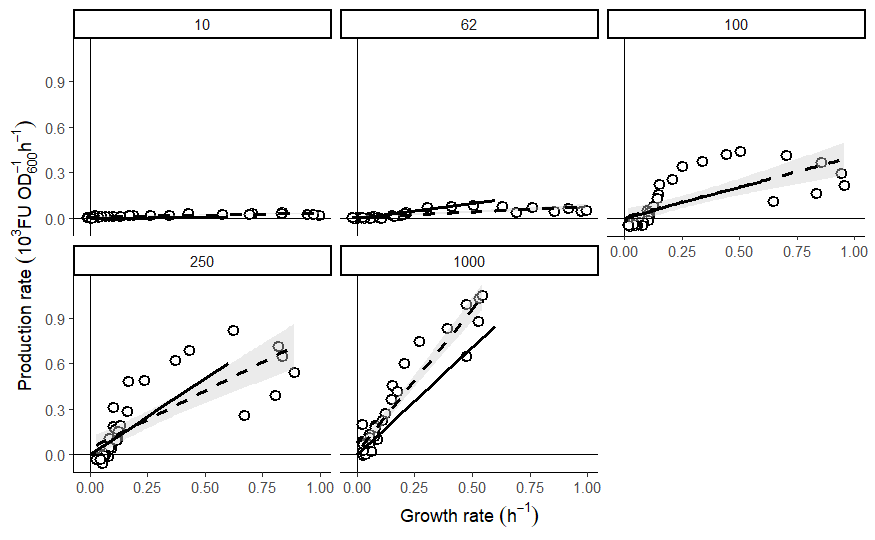

```r
compare_plot <- hill_prediction(data = MG1655_lacI_tidy,
                                model_fit = predictions,
                                time_interval = time_range,
                                growth_interval = c(0,0.6))
print(compare_plot)
```

Ultimately, we compare the results for every IPTG biosensor.

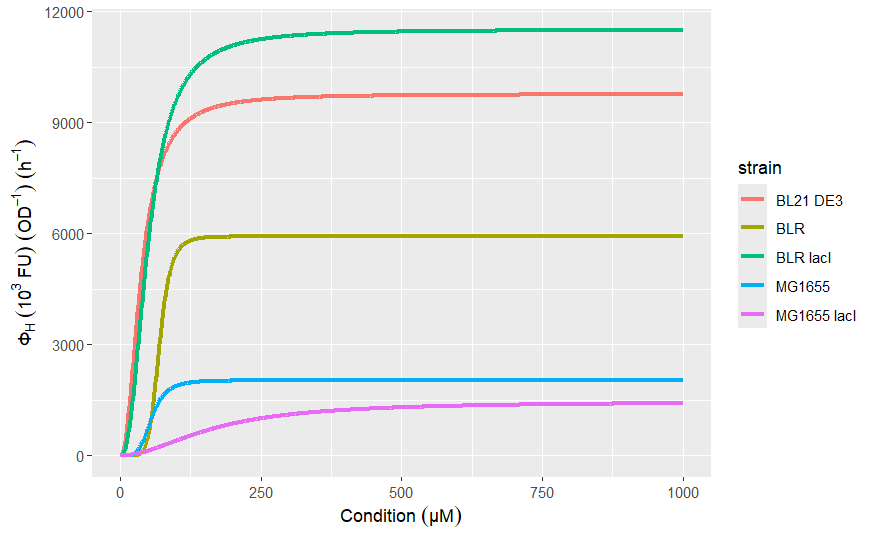

```r
hill_comparison %>%
  mutate(strain = as.factor(strain)) %>%
  ggplot(data = ., aes(x = Condition, y = fi, color = strain)) +
  geom_path(size = 1.25)+
  xlab(expression(Condition~(μM))) +
  ylab(expression(Φ[H]~(10^3~FU)~(OD^-1)~(h^-1)))
```